# Data Analytics Project

By Mateusz Ulinski, Roberta Lescikauskaite, Leszek Olko

# Irish Crime Statistics

This project is based on the Crimes per Garda Station dataset, which shows the different crimes at each Garda station in Ireland, between the years 2003 and 2016. We chose this dataset, because it is interesting to have a look about crimes tendency during the years in different districts. Comparing crime statistics between garda divisions, we should focus on long-term trends rather than on direct comparison of crime rates of any year, because data may depend on a wide range of factors, such as the effectiveness of Garda work, different people’s social class, demographic, economic, cultural, political situations. In addition, Garda may not record all the crimes. The crime in various ways relates to the social, demographic, economic, legal, political and moral situation of the society, its development and changes. When the country’s situation is strong, the level of crime remains unchanged. Social and economic crisis has a huge impact in periods crime usually increases.

## Our Data Set

### Questions about our Data

By just looking at the data, multiple questions can be formed. Such as:

- Is crime going down?
- Are certain areas more prone to crime than others?
- Which is the safest area to live?

We will try to answer the following questions:

- What is the most dangerous area in Ireland? Is there a discrepancy in the crime rates between different areas? -Mateusz
- Historically, how did the crime in this area change? -Mateusz
- How do the different crimes correlate to each other, does more of one crime mean more of another? -Mateusz
- Does the number of controlled drug offences correlate to the number of other crimes? - Roberta
- What is the most common crime in Ireland? - Roberta
- Overall, is the amount of crime going up or down? - Roberta
- Which area had the largest decrease in crime between 2003 and 2016? - Roberta
- Which year had the highest amount of crime? - Leszek
- Which area had the largest increase in crime between 2003 and 2016? - Leszek
- Is there more damages to the property or more burglary(make hypothesis)? -Leszek

### The variables in our Data - Roberta Lescikauskaite

The nominal variables in our dataset are:

- Station
- Division

The rest of the variables are on the ratio scale, each of these can be seen for every year from 2003 to 2016

- Attempts to threat or murder
- Dangerous or negligent acts
- Kidnapping and related offences
- Robbery extortion and hijacking
- Burglary and related offences
- Theft and related offences
- Fraud and deception offences
- Controller drug offences
- Weapons and explosive offences
- Damage to property and to the environement
- Public order and other social code offences
- Offences against government, justice procedures and organisation of crimes

|  | Total Number of Crimes |
| --- | --- |
| Murders | 198554 |
| Dangerous Acts | 169840 |
| Kidnapping | 1433 |
| Burglary | 35047 |
| Theft | 343398 |
| Robbery | 1001206 |
| Fraud | 65167 |
| Drugs | 214910 |
| Weapons | 40166 |
| Damage to Property | 480010 |
| Disorder | 642108 |
| Organised Crime | 130696 |

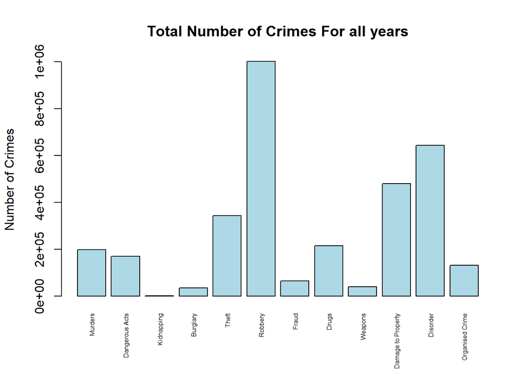

## Descriptive Statistics - Roberta Lescikauskaite

In this section we’re going to describe our dataset in terms of central tendency, mean, variance and standard deviation.

### Murders 2003~2016

Let’s take a look at the *Attempts or threats to murder, assaults, hrassments and related offences* data from 2004

```
##    Min. 1st Qu.  Median    Mean 3rd Qu.    Max.
##    0.00    3.00    8.00   23.58   23.00  429.00
```

And the same from 2016

```
##    Min. 1st Qu.  Median    Mean 3rd Qu.    Max.
##   0.000   0.000   2.000   6.853   6.000 158.000
```

From this we can see that there’s been an overall decrease in that specific category over the 12 year period. This is an *Attempts or threats to murder, assaults, hrassments and related offences* data in 2016.

Let’s take a short look at the central tendancy of a few other crimes in different years

```r
mean(crimes$Attempts.or.threats.to.murder..assaults..harassments.and.related.offences.2016)
```

```
## [1] 6.852575
```

```r
mean(crimes$Dangerous.or.negligent.acts.2015.)
```

```
## [1] NA
```

```r
mean(crimes$Weapons.and.Explosives.Offences.2013)
```

```
## [1] 4.884547
```

```r
mean(crimes$Theft.and.related.offences.2014)
```

```
## [1] 138.0053
```

```r
mean(crimes$Robbery..extortion.and.hijacking.offences.2012)
```

```
## [1] 5.003552
```

```r
mean(crimes$Fraud..deception.and.related.offences.2011.)
```

```
## [1] NA
```

```r
mean(crimes$Public.order.and.other.social.code.offences.2010.)
```

```
## [1] NA
```

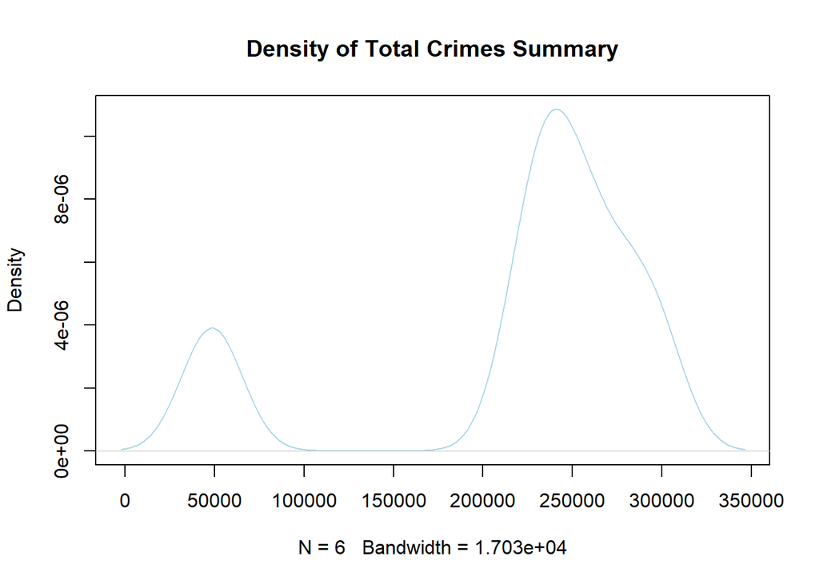

```r
summarycrimes <- getAllYears(crimes)
addedsummary <- summary(summarycrimes)
plot(density(addedsummary), main="Density of Total Crimes Summary", col="lightblue", type="l")
```

```r
range(addedsummary)
```

```
## [1]  48578 295187
```

### Visualising our Data - Mateusz Ulinski

In this section we will visualize our data by comparing murder rates for each division in 2004 and 2016.

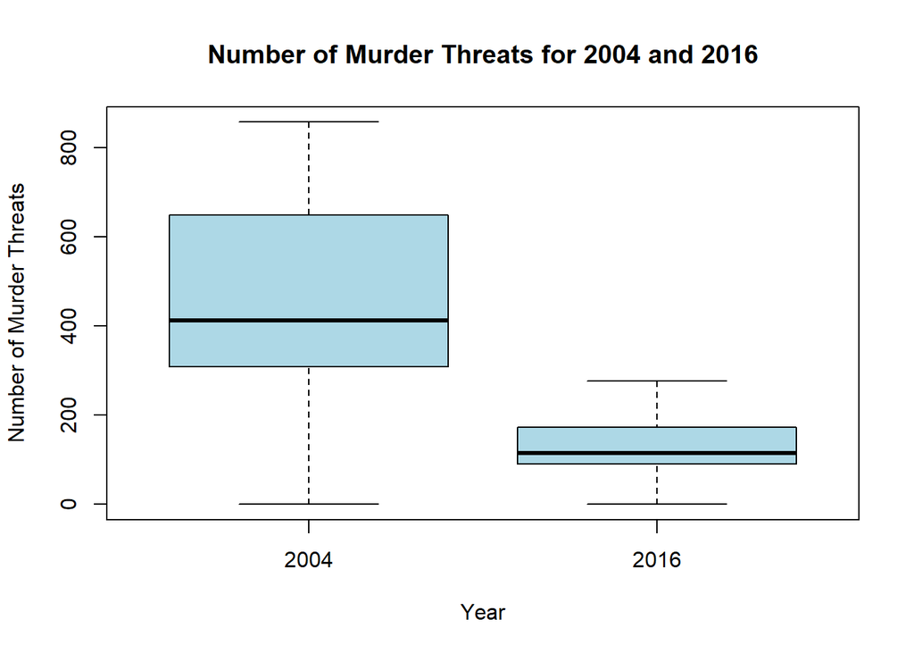

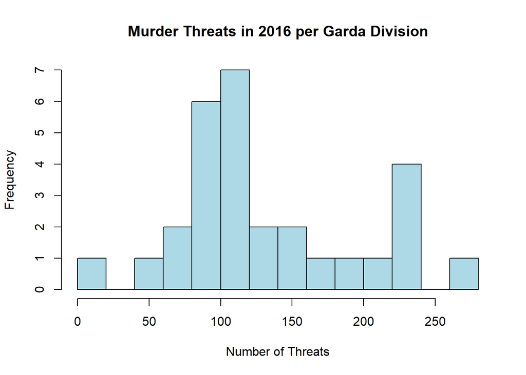

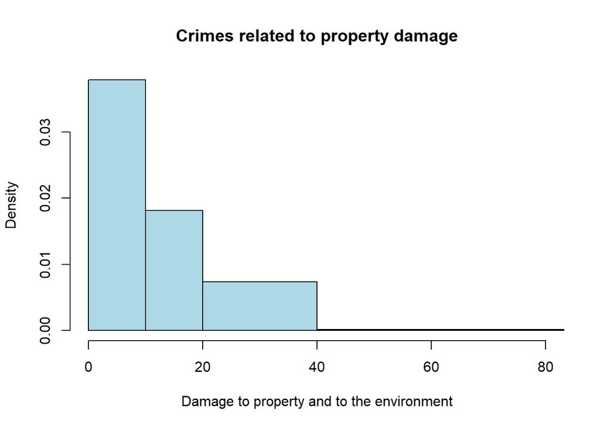

```r
hist(crimes$Damage.to.property.and.to.the.environment.2010, breaks=c(0,10,20,40,2000), xlab="Damage to property and to the environment", main="Crimes related to property damage", col="lightblue", freq=F, xlim=c(0,80), axes=T )
```

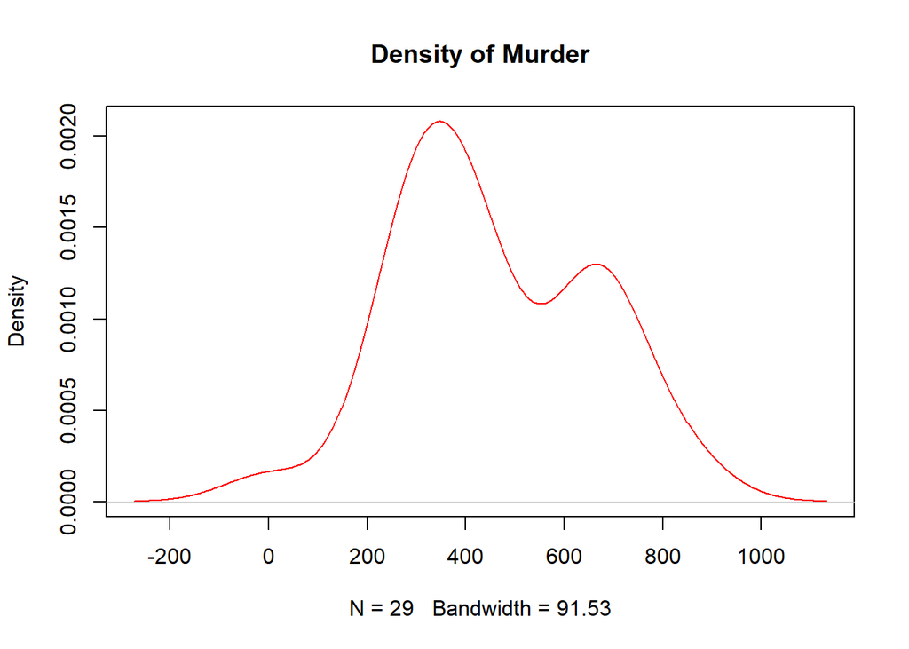

```r
plot(density(murders.2004$number.of.threats), main="Density of Murder", col="red", type="l")
```

### Crimes in 2010 - Roberta Lescikauskaite, Mateusz Ulinski, Leszek Olko

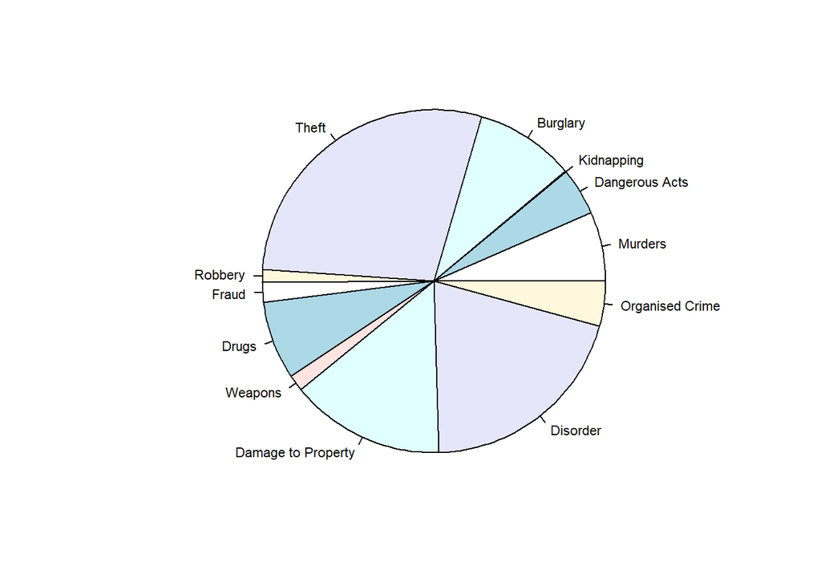

As we can see from our Pie Chart that the most popular crime in 2010 was *Theft and related offences*.

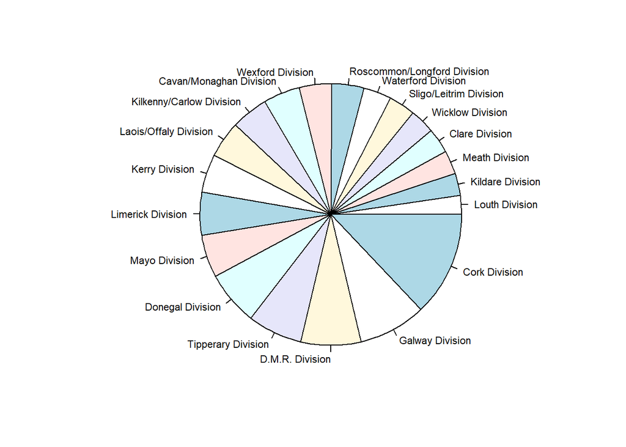

```r
stations.per.division <- table(crimes$Divisions)
x <- 0
x <- x + stations.per.division['Cork North Division']
x <- x + stations.per.division['Cork City Division']
x <- x + stations.per.division['Cork West Division']

stations.per.division['Cork Division'] <- x
stations.per.division <- stations.per.division[-which(names(stations.per.division) %in% c('Cork North Division', 'Cork City Division', 'Cork West Division'))]

y <- 0
y <- y + stations.per.division['D.M.R. Eastern Division']
y <- y + stations.per.division['D.M.R. North Central Division']
y <- y + stations.per.division['D.M.R. Northern Division']
y <- y + stations.per.division['D.M.R. South Central Division']
y <- y + stations.per.division['D.M.R. Southern Division']
y <- y + stations.per.division['D.M.R. Western Division']

##grep('D.M.R.*', names(stations.per.division))

stations.per.division['D.M.R. Division'] <- y
stations.per.division <- stations.per.division[-which(names(stations.per.division) %in% c('D.M.R. Eastern Division', 'D.M.R. North Central Division', 'D.M.R. South Central Division', 'D.M.R. Southern Division','D.M.R. Western Division', 'D.M.R. Northern Division'))]

z <- 0
z <- z + stations.per.division['Westmeath Division']
z <- z + stations.per.division['Westmeath']

stations.per.division['Westmeath Division'] <- z
stations.per.division <- stations.per.division[-which(names(stations.per.division) %in% c('Westmeath', 'Westmeath Division'))]

pie(sort(stations.per.division), radius=1, cex=0.7)
```

## Distribution of our Data - Roberta Lescikauskaite

In this section we’re going to look at the distribution of different variables in our data, using a Cullen and Frey graph we will try to identify and fit the variables to a common distribution if possible.

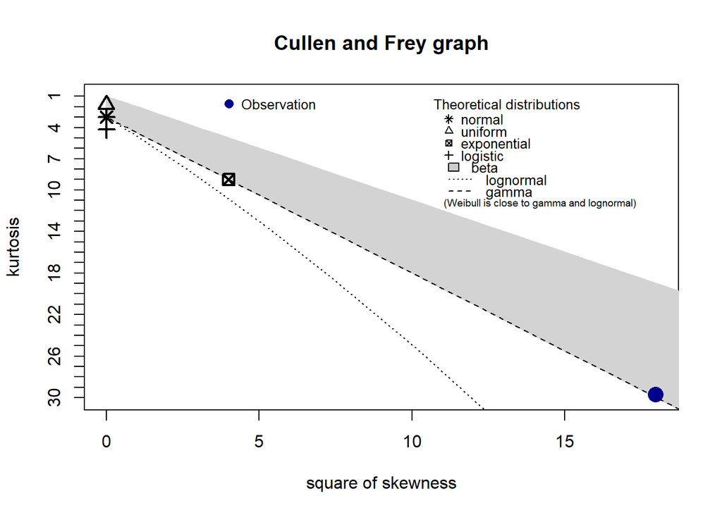

```
## summary statistics
## ------
## min:  0   max:  429
## median:  8
## mean:  23.58259
## estimated sd:  43.0803
## estimated skewness:  4.238063
## estimated kurtosis:  29.68319
```

```r
library(fitdistrplus)
descdist(crimes$Attempts.or.threats.to.murder..assaults..harassments.and.related.offences.2004)
```

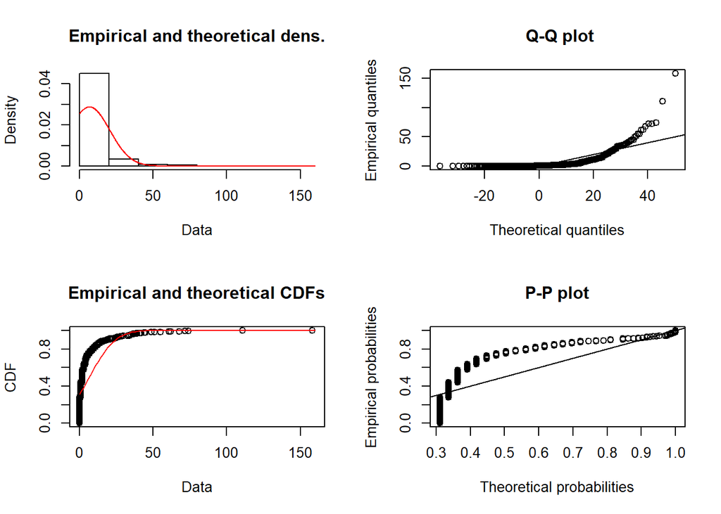

```r
normal_test <- fitdist(crimes$Attempts.or.threats.to.murder..assaults..harassments.and.related.offences.2016., "norm")
plot(normal_test)
```

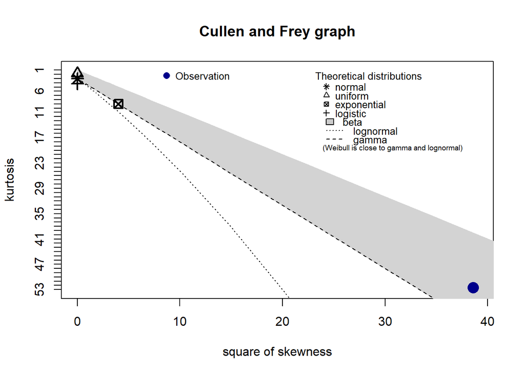

```
## summary statistics
## ------
## min:  0   max:  33
## median:  0
## mean:  0.9253996
## estimated sd:  2.951225
## estimated skewness:  6.210532
## estimated kurtosis:  52.55821
```

```r
descdist(crimes$Weapons.and.Explosives.Offences.2016.)
```

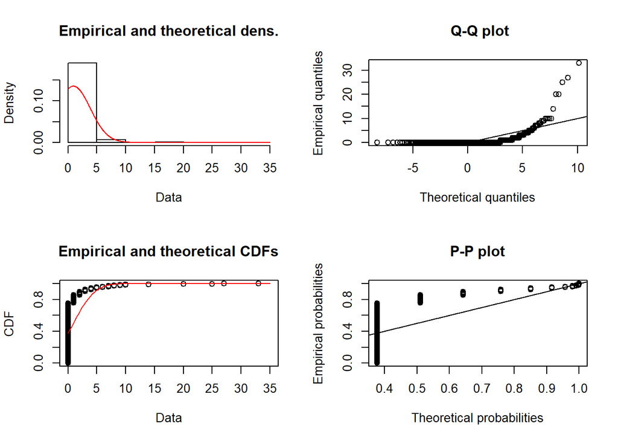

```r
normal_test <- fitdist(crimes$Weapons.and.Explosives.Offences.2016., "norm")
plot(normal_test)
```

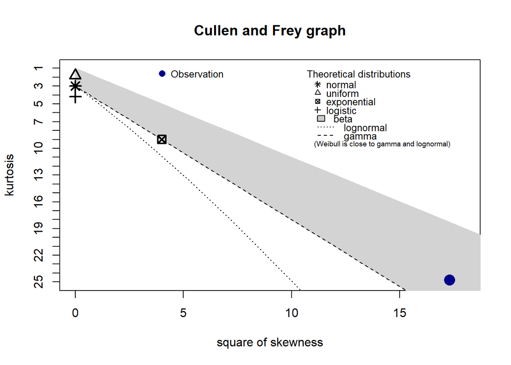

```
## summary statistics
## ------
## min:  0   max:  171
## median:  2
## mean:  8.900533
## estimated sd:  19.43821
## estimated skewness:  4.159374
## estimated kurtosis:  24.78684
```

```r
descdist(crimes$Burglary.and.related.offences.2016.)
```

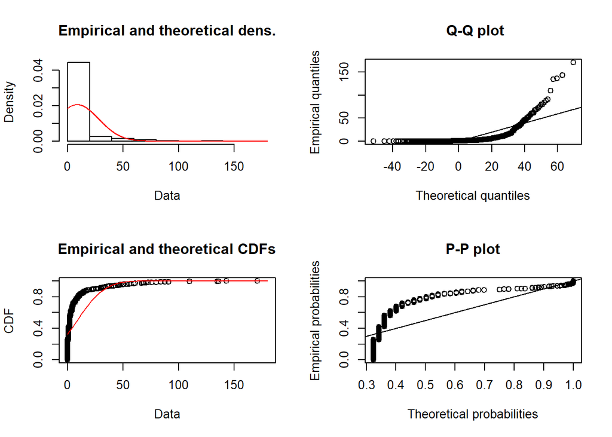

```r
normal_test <- fitdist(crimes$Burglary.and.related.offences.2016., "norm")
plot(normal_test)
```

## Inferential Statistics

### Crimes in Areas - Mateusz Ulinski

#### Introduction

I will try to answer these three questions:

- What is the most dangerous area in Ireland? Is there a discrepancy in the crime rates between different areas?
- Historically, how did the crime in this area change?
- How do the differnet crimes correlate to eachother, does more of one crime mean more of another?

##### Method

To answer these questions I will seperate the data into the 4 provinces of Ireland: Leinster, Munster, Ulster and Connacht on which I will conduct various statistics.

The location of the Garda Station is a nominal variable, while all the crime figures are intervals.

We first have to check if there is a discrepancy between the different areas, to do this we’re going to do a hypothesis test:

H1: There is a discrepancy between the amount of crime in different areas of Ireland H0: There is no discrepancy between the amount of crime in different areas of Ireland

#### Statistics

Lets take a closer look at our data, first lets get the average number of crimes in each Province in the years between 2003 and 2016:

Crimes Per Province 2003 - 2016

|  | Average Crimes Per Year |
| --- | --- |
| Leinster | 147403.57 |
| Munster | 57803.79 |
| Connacht | 20490.93 |
| Ulster | 11581.71 |

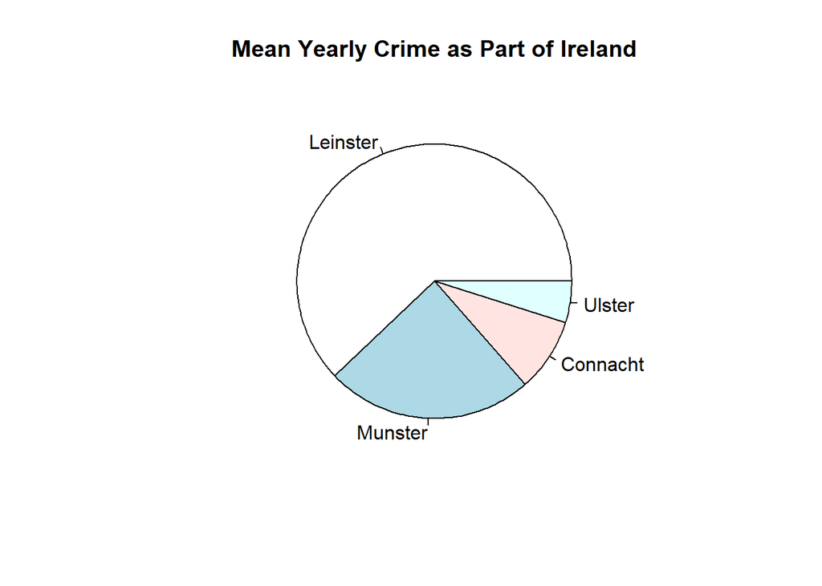

From this graph we can understand that over 50% of crimes commited yearly happen in Leinster, this could be due to the population disrecpency between the provinces. So far the data is pointing to rejecting the null hypothesis and accepting that there is a discrepancy between the regions.

Let’s see what happens when we normalize the data a bit, using population data from the 2016 census, which is limiting us to only looking at 2016 crime rates. We normalize the data to get a better representation of the crimes, area with less people will naturally have less crime overall, but when you take a look at crimes per person you can get a more accurate picture.

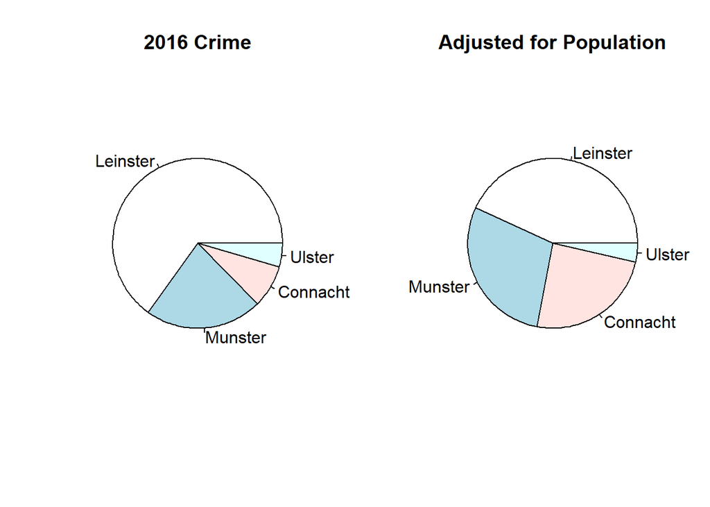

This tells us a bit of a different story, after adjusting for population we can see that Crime per Person in Connacht is a lot higher than in Ulster, while in the unadjusted chart it looked very similar.

From this we can infer that Ulster is the safest province in Ireland, while Leinster and Munster are the most dangerous.

Thus there is indeed discrepancy in crimes between the different regions in Ireland, making us reject the null hypothesis and accept the alternative hypothesis.

We have used a pie chart here to visually represent the proportional difference between crimes in the 4 provinces.

##### Closer look at Leinster

Let us take a closer look at Leinster, to see how Leinster changed over the years, and which parts are the most dangerous. We’re first going to take a look at the Distribution of Crimes between different Garda Divisions in Leinster

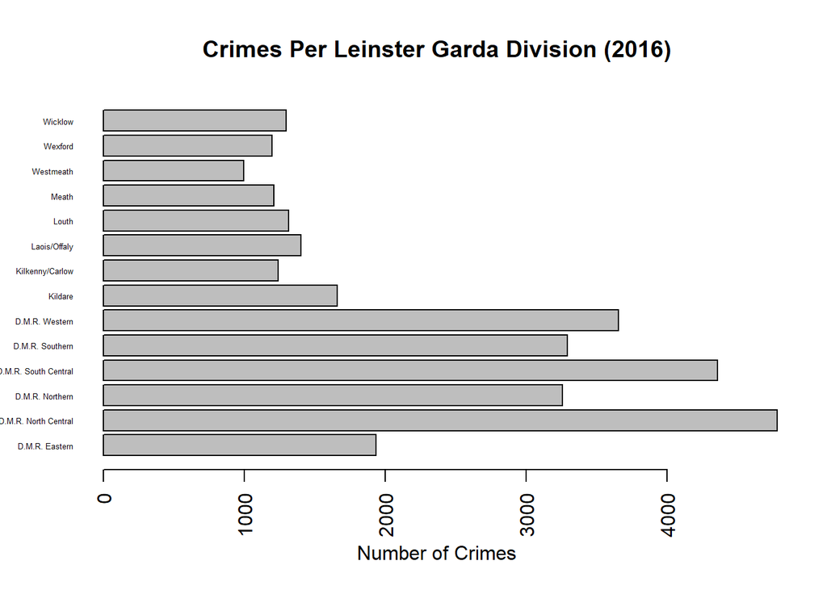

From this graph we can clearly see that Dublin North Central had the most crimes in Leinster in 2016, totalling up at 4783! Looking closer at Dublin North Central we can see that it covers the Garda Stations located at Bridewell Dublin, Fitzgibbon Street, Mountjoy, Store Street, these Garda Stations reported the most crime in 2016.

The barplot allows us to visually compare the different divisions in Leinster, easily being able to see how differnet divisions relate to eachother.

#### Leinster Over The Years

If we take a look at the sum of crimes in Leinster over the years

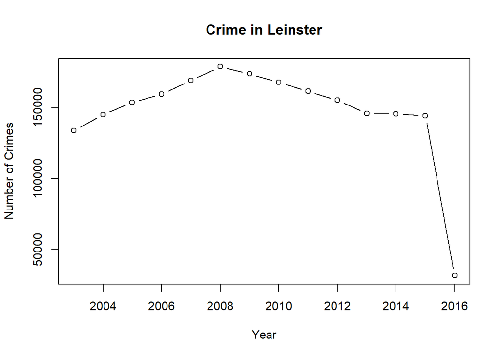

The line graph here shows us how the crimes have changed in a easy to understand way, up is more, down is less, it is very visually clear to the reader.

#### Deep into Crime

Here we’re going to examine how differnet crimes relate to eachother, we’re going to use Pearsons Correlation Co-Efficient to examine linear relationships between the data.

Lets take a look at a few scatterplots using data from 2016

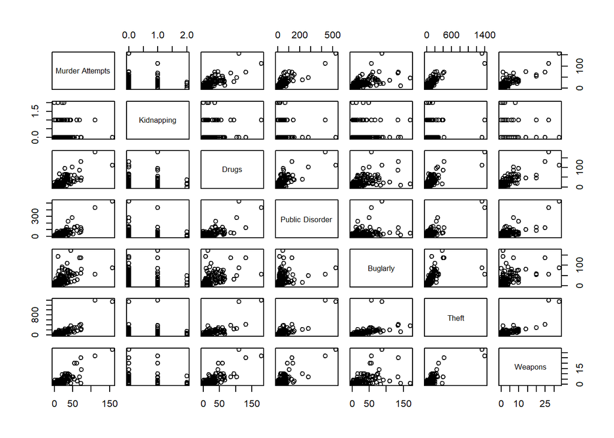

The scatterplots here show us the correlation of a lot of different variables to eachother, allowing us to quickly judge where a correlation could exist by looking at the chart, which lets us pick the appropriate combinations for further testing.

From looking at the scatterplots we can see that some of our chosen crimes seem to have a correlation with eachother, lets take a closer look at some of them

#### Drugs and Murder

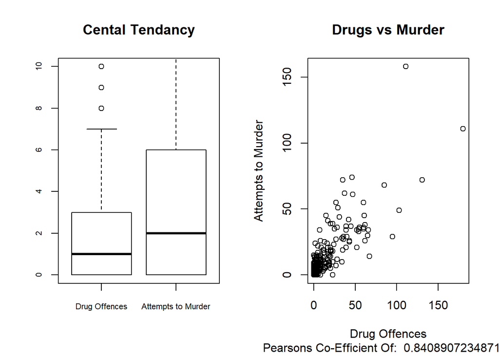

Judging by the graphs and the Perasons co-efficient, there is a strong positive correlation between the two, meaning that attempts to murder can be linked to the use of drugs.

#### Burglary and Theft

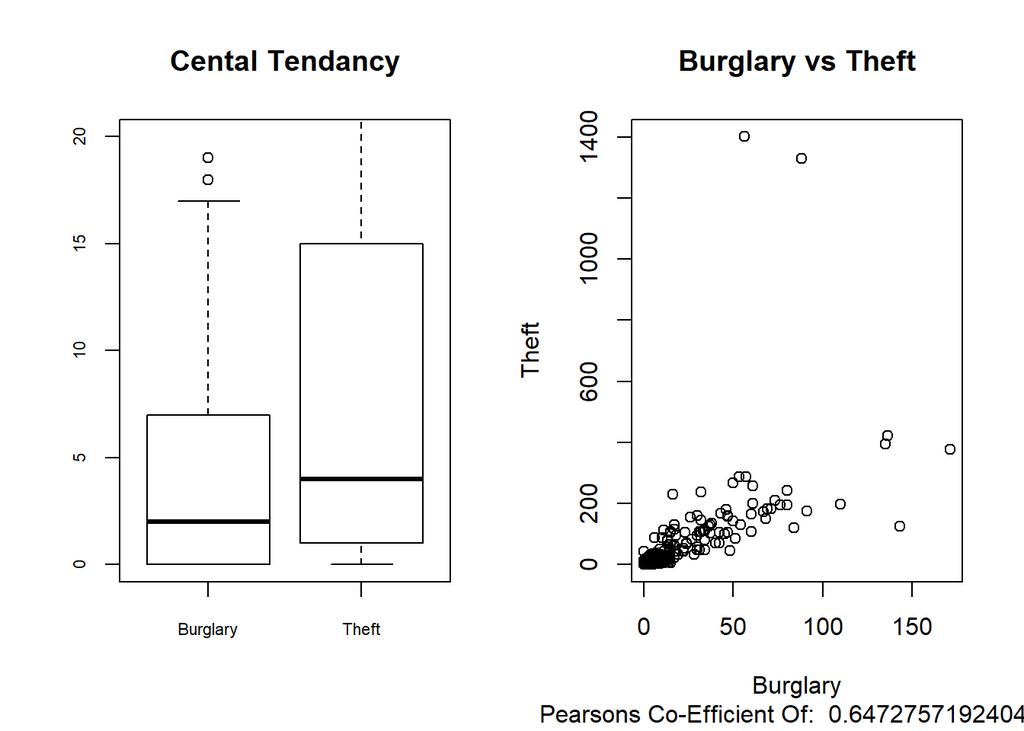

Looking at Burglary vs Theft, the correlation is weaker than that of Drugs and Murder, there might be some correlation between the two but it is not certian.

#### Summary

From looking at the data, we have answered the questions:

- What is the most dangerous area in Ireland? Is there a discrepancy in the crime rates between different areas?
- Historically, how did the crime in this area change?
- How do the differnet crimes correlate to eachother, does more of one crime mean more of another?

### Method

We will take a look at the pairs scatterplot created plot by Mateusz above, and choose some pairs of variables to analyze deeper using Pearson’s Correlation and barplots.

#### Pearson’s Correlation

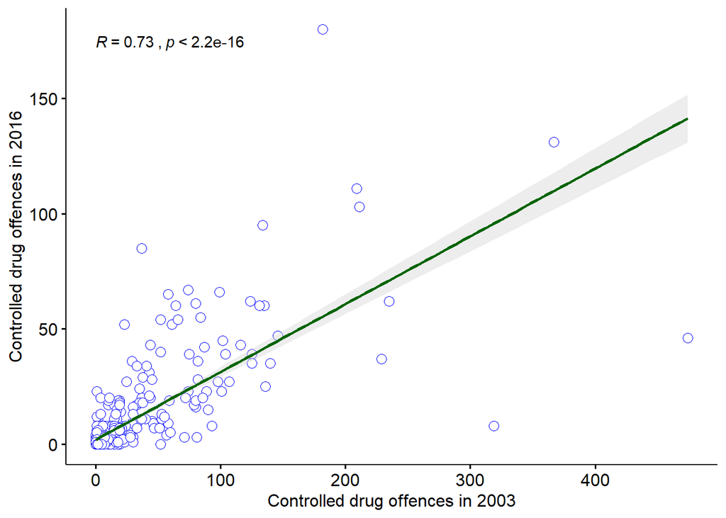

```r
library("ggpubr")
ggscatter(crimes, x='Controlled.drug.offences.2003', y='Controlled.drug.offences.2016.', color='blue', shape = 21, size = 3, conf.int=TRUE, cor.coef = TRUE, cor.method='pearson', add="reg.line", add.params = list(color = "darkgreen", fill = "lightgray"), xlab='Controlled drug offences in 2003', ylab='Controlled drug offences in 2016')
```

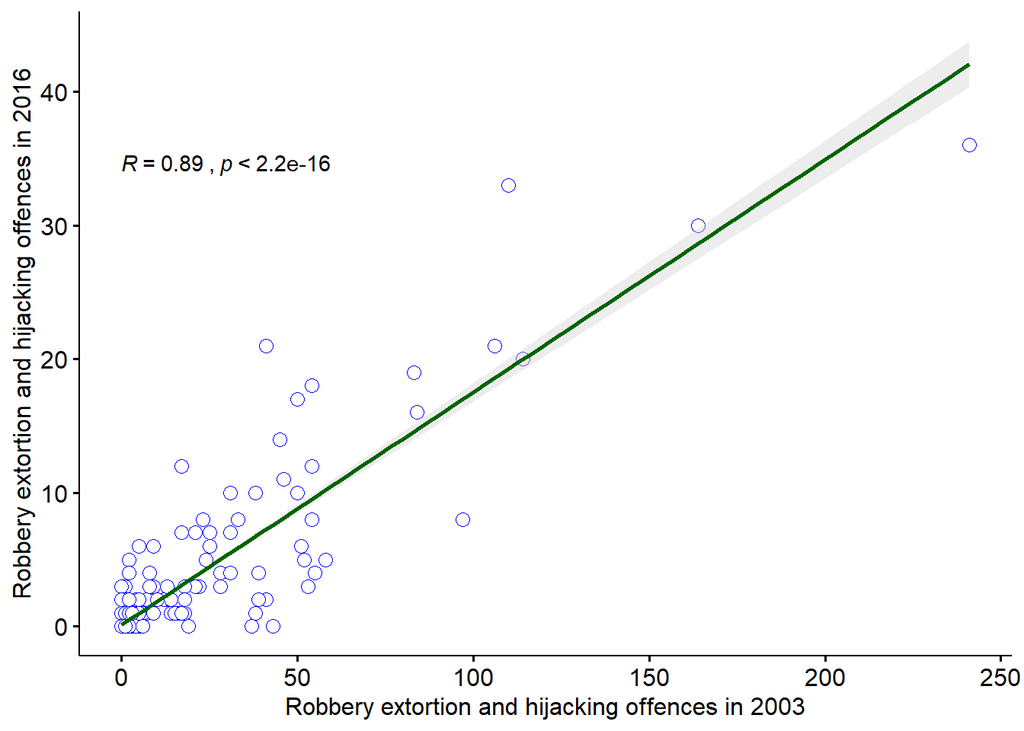

```r
ggscatter(crimes, x='Robbery..extortion.and.hijacking.offences.2003', y='Robbery..extortion.and.hijacking.offences.2016.',color='blue', shape = 21, size = 3, conf.int=TRUE, cor.coef = TRUE, cor.method='pearson', add="reg.line",add.params = list(color = "darkgreen", fill = "lightgray"), xlab="Robbery extortion and hijacking offences in 2003", ylab = "Robbery extortion and hijacking offences in 2016")
```

#### Highest amount of crimes in all years

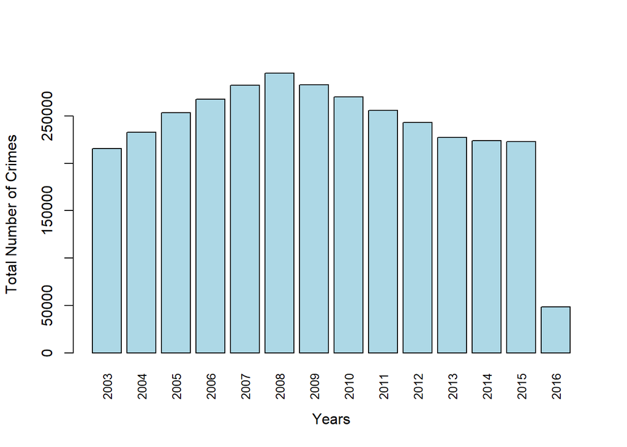

```r
sumcrimes <- getAllYears(crimes)
barplot(sumcrimes, names.arg=c(2003:2016), xlab="Years", ylab="Total Number of Crimes", col="lightblue",las=3,  cex.names=.8)
```

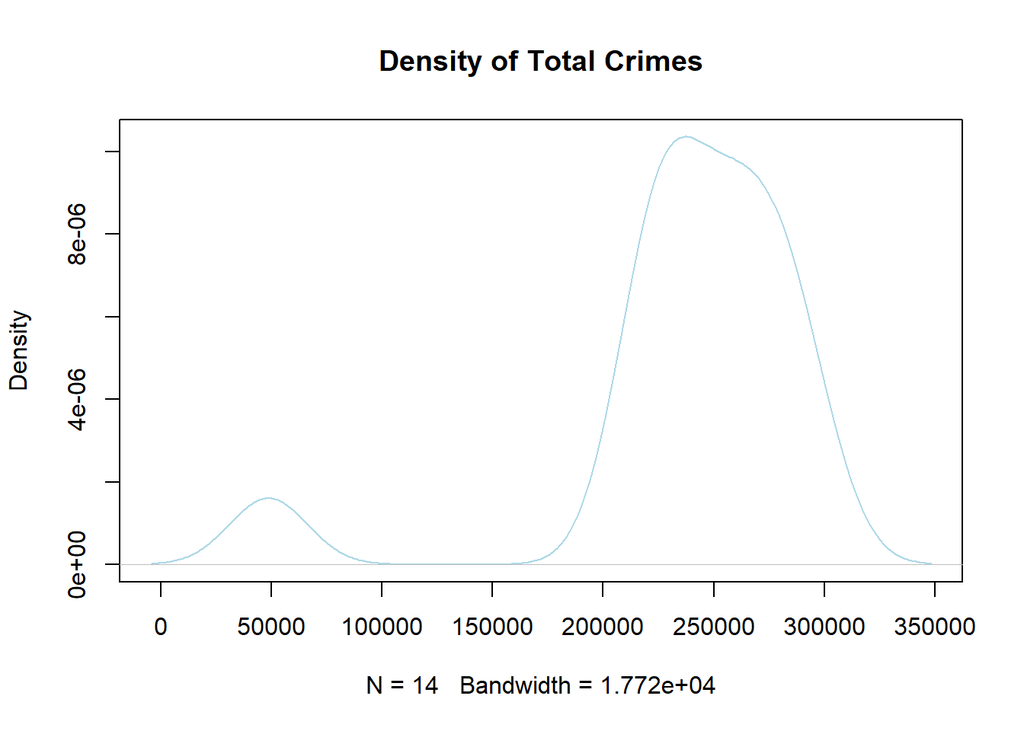

```r
plot(density(sumcrimes), main="Density of Total Crimes", col="lightblue", type="l")
```

```r
summary(sumcrimes)
```

```
##    Min. 1st Qu.  Median    Mean 3rd Qu.    Max.
##   48578  224843  248236  237324  269572  295187
```

### Summary

#### Introduction

In this section I am going to answer the questions:

- Which year had the highest amount of crime?
- Which area had the largest increase in crime between 2003 and 2016?
- Is there more damages to the property or more burglary(make hypothesis)?